# Mendelian Randomization Report

Mitochondrial DNA Copy Number as a Hidden Player in the Progression of Multiple Sclerosis: A Bidirectional Two-Sample Mendelian Randomization Study

Created by Mahdi Akbarzadeh (email: akbarzadeh.ms@gmail.com), Hani Sabaie, and Ali Taghavi Rad

2024-10-04

#### Authors List:

1. Hani Sabaie
2. Ali Taghavi Rad
3. Motahareh Shabestari
4. Danial Habibi
5. Toktam Saadattalab
6. Sahar Seddiq
7. Amir Hossein Saeidian
8. Asiyeh Sadat Zahedi
9. Maryam Sanoie
10. Hassan Vahidnezhad
11. Maryam Zarkesh
12. Laleh Foroutani
13. Hakon Hakonarson
14. Fereidoun Azizi
15. Mehdi Hedayati
16. Maryam Sadat Daneshpour
17. Mahdi Akbarzadeh

#### Abbreviations:

- GWAS: Genome-Wide Association Studies
- MR: Mendelian Randomization
- MSP: Multiple Sclerosis Progression
- mtDNA-CN: Mitochondrial DNA Copy Number
- SNP: Single Nucleotide Polymorphism

# Bidirectional MR Analysis

## mtDNA-CN on MSP

### Title: Exploring the Causal Impact of **mtDNA-CN** on **MSP**

> Introduction
- Exposure: mtDNA-cn | GWAS summary statistics: [GWAS catalogue](https://www.ebi.ac.uk/gwas/publications/35023831) | Reference paper: [Chong et al. 2022](https://pubmed.ncbi.nlm.nih.gov/35023831/)
- Sample size: 383,476
- Ancestry: European
- Outcome: MSP | GWAS summary statistics: [International Multiple Sclerosis Genetics Consortium (IMSGC)](https://imsgc.net/?page_id=31) | Reference paper: [Harroud et al. 2023](https://pubmed.ncbi.nlm.nih.gov/37380766/)
- Sample size: 12,584
- Ancestry: European

> Data Prepration
- Number of total SNPs in exposure: 11,453,766 SNPs
- Number of SNPs exposure with p-value < $5\times10^{-8}$: 6,694 SNPs
- Number of SNPs exposure after clumping: 66 SNPs
- Number of total SNPs in outcome: 7,776,916 SNPs
- Number of common variants between exposure and outcome: 62 SNPs
- Number of SNPs after harmonization (action=2): 54 SNPs
- A total of eight SNPs (rs10835540, rs12052715, rs17850455, rs2038480, rs289713, rs342293, rs72660908, rs8176645) were removed due to being palindromic.

> Weakness of Instruments

```
##    Min. 1st Qu.  Median    Mean 3rd Qu.    Max.
##   29.54   39.92   56.07   91.96  108.06  441.00
```

The number of SNPs eliminated through the process of checking for weakness: 0 SNP

> Initial MR

```
##   id.exposure id.outcome outcome exposure                    method nsnp
## 1      xd1Q5E     AOkvNF outcome exposure                  MR Egger   54
## 2      xd1Q5E     AOkvNF outcome exposure           Weighted median   54
## 3      xd1Q5E     AOkvNF outcome exposure Inverse variance weighted   54
## 4      xd1Q5E     AOkvNF outcome exposure               Simple mode   54
## 5      xd1Q5E     AOkvNF outcome exposure             Weighted mode   54
##             b         se      pval
## 1 -0.06515392 0.18192535 0.7216917
## 2 -0.06021617 0.11394908 0.5971884
## 3 -0.01181587 0.08002757 0.8826210
## 4 -0.03408639 0.24885219 0.8915700
## 5 -0.13223047 0.17563767 0.4548656
```

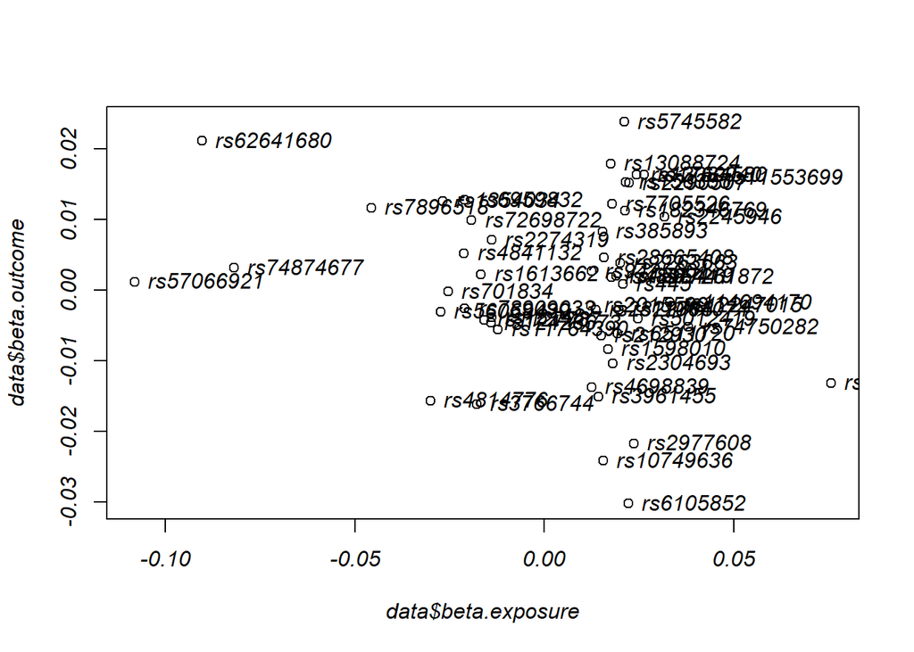

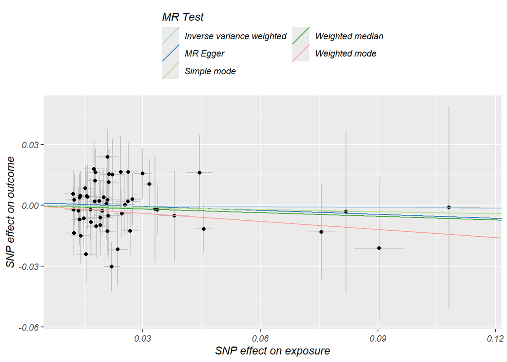

```
##   id.exposure id.outcome outcome exposure                    method        Q
## 1      xd1Q5E     AOkvNF outcome exposure                  MR Egger 36.58355
## 2      xd1Q5E     AOkvNF outcome exposure Inverse variance weighted 36.69013
##   Q_df    Q_pval
## 1   52 0.9480921
## 2   53 0.9570435
```

```
##   id.exposure id.outcome outcome exposure egger_intercept          se      pval
## 1      xd1Q5E     AOkvNF outcome exposure     0.001424528 0.004363427 0.7453792
```

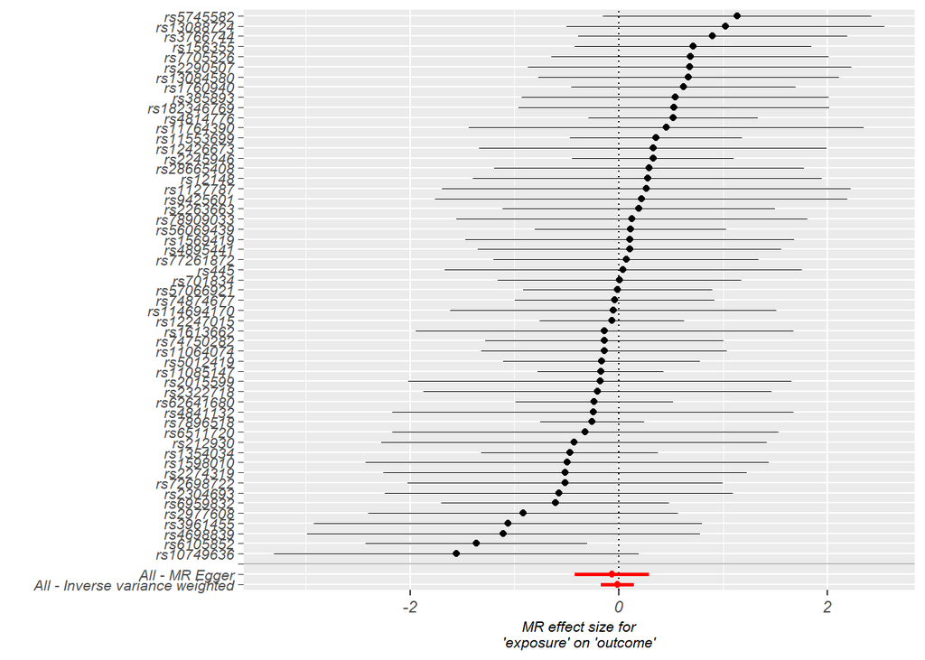

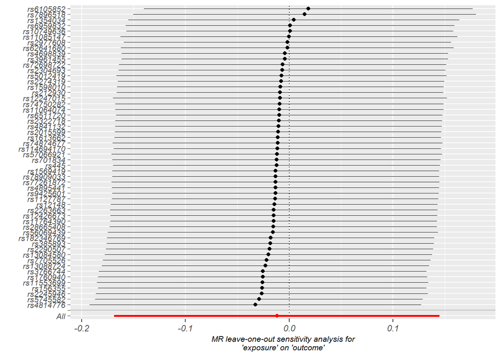

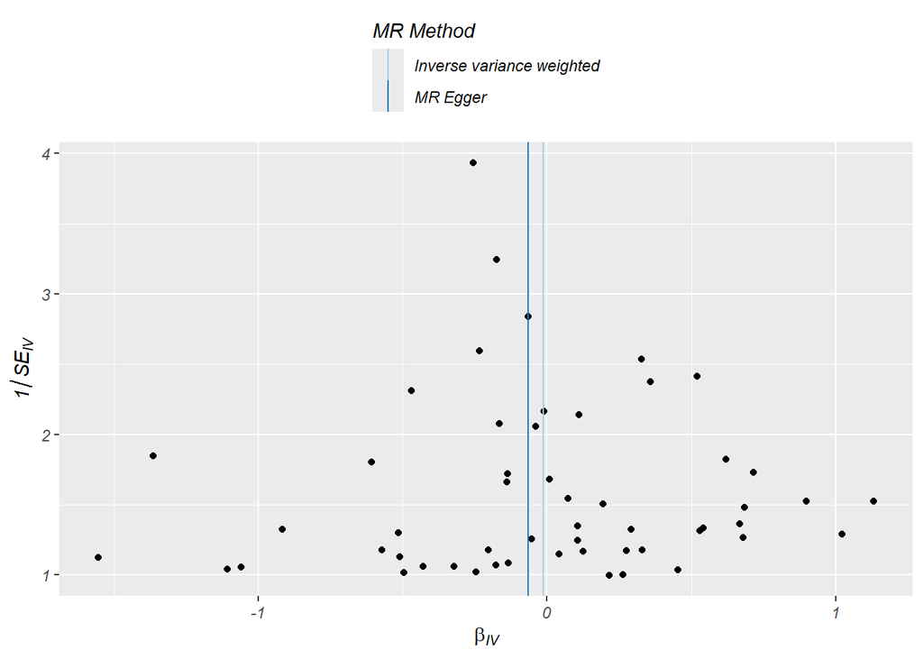

> MR-PRESSO Test

```
## $`Main MR results`
##        Exposure       MR Analysis Causal Estimate         Sd     T-stat
## 1 beta.exposure               Raw     -0.01181587 0.06658499 -0.1774554
## 2 beta.exposure Outlier-corrected              NA         NA         NA
##     P-value
## 1 0.8598271
## 2        NA
##
## $`MR-PRESSO results`
## $`MR-PRESSO results`$`Global Test`
## $`MR-PRESSO results`$`Global Test`$RSSobs
## [1] 38.22615
##
## $`MR-PRESSO results`$`Global Test`$Pvalue
## [1] 0.9568
```

> RadialMR Test

```
##
## Radial IVW
##
##                     Estimate  Std.Error    t value  Pr(>|t|)
## Effect (Mod.2nd) -0.01181590 0.06658498 -0.1774560 0.8591502
## Iterative        -0.01181590 0.06658498 -0.1774560 0.8591502
## Exact (FE)       -0.01190537 0.08002775 -0.1487656 0.8817386
## Exact (RE)       -0.01188969 0.06802169 -0.1747927 0.8619086
##
##
## Residual standard error: 0.832 on 53 degrees of freedom
##
## F-statistic: 0.03 on 1 and 53 DF, p-value: 0.86
## Q-Statistic for heterogeneity: 36.68996 on 53 DF , p-value: 0.9570454
##
##  No significant outliers
## Number of iterations = 2
```

```
## [1] "No significant outliers"
```

> Standardized Residuals

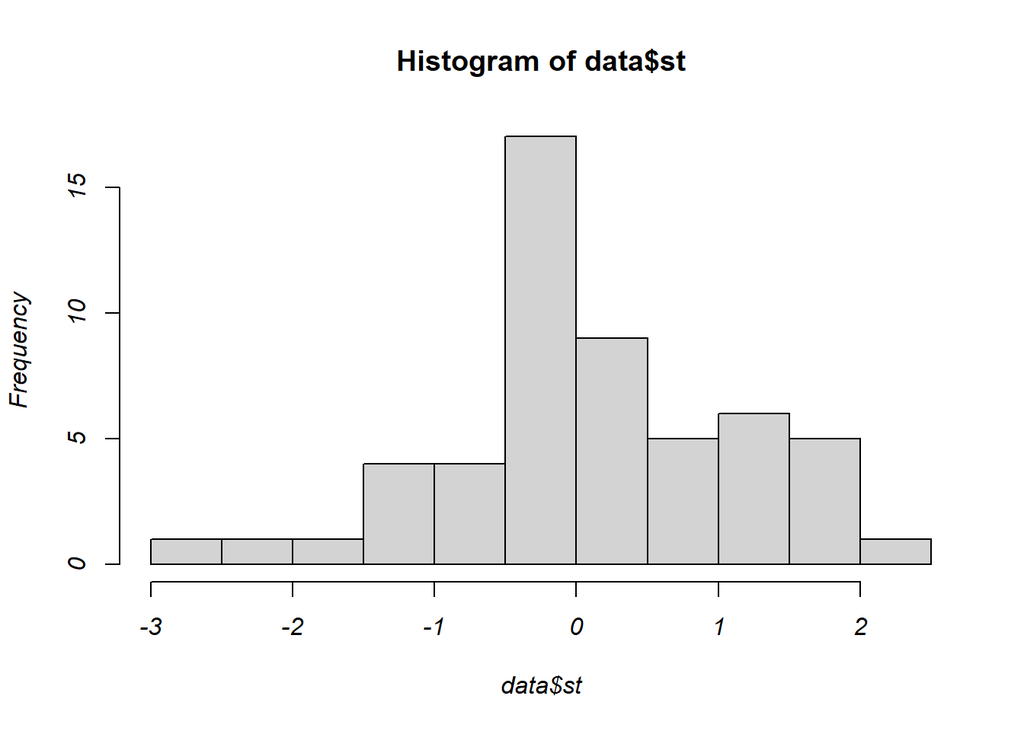

```
## integer(0)
```

> Cook’s Distance

“In statistics, Cook’s distance or Cook’s D is a commonly used estimate of the influence of a data point when performing a least-squares regression analysis. In a practical ordinary least squares analysis, Cook’s distance can be used in several ways: to indicate influential data points that are particularly worth checking for validity; or to indicate regions of the design space where it would be good to be able to obtain more data points. It is named after the American statistician R. Dennis Cook, who introduced the concept in 1977” ([Refernce](https://en.wikipedia.org/wiki/Cook%27s_distance)).

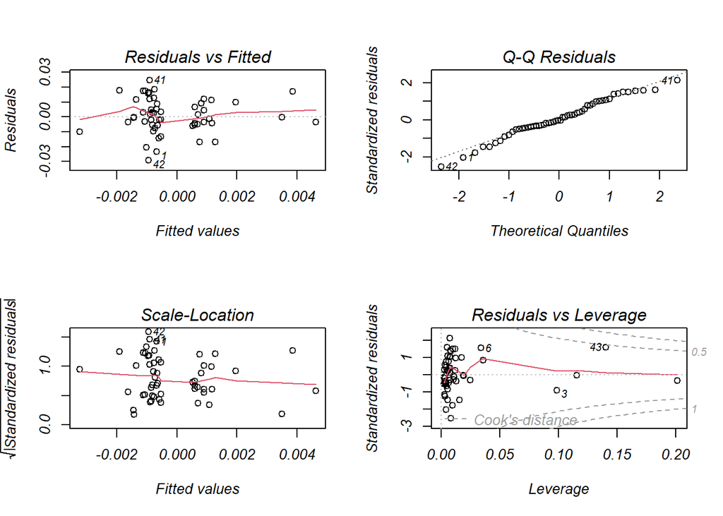

> Potential Outliers and Influential SNPs

```
## rs10749636 rs11085147 rs11553699 rs5745582 rs6105852 rs62641680 rs4814776 rs156355 rs3766744 rs1760940 rs7705526
```

> MR Analysis After Deleting Outliers and Influential SNPs

```
##   id.exposure id.outcome outcome exposure                    method nsnp
## 1      xd1Q5E     AOkvNF outcome exposure                  MR Egger   43
## 2      xd1Q5E     AOkvNF outcome exposure           Weighted median   43
## 3      xd1Q5E     AOkvNF outcome exposure Inverse variance weighted   43
## 4      xd1Q5E     AOkvNF outcome exposure               Simple mode   43
## 5      xd1Q5E     AOkvNF outcome exposure             Weighted mode   43
##              b         se      pval
## 1 -0.099655757 0.23410418 0.6725602
## 2 -0.063269624 0.13167989 0.6308858
## 3 -0.066336669 0.09551918 0.4873779
## 4 -0.001375637 0.24308226 0.9955115
## 5 -0.095233755 0.20215017 0.6400043
```

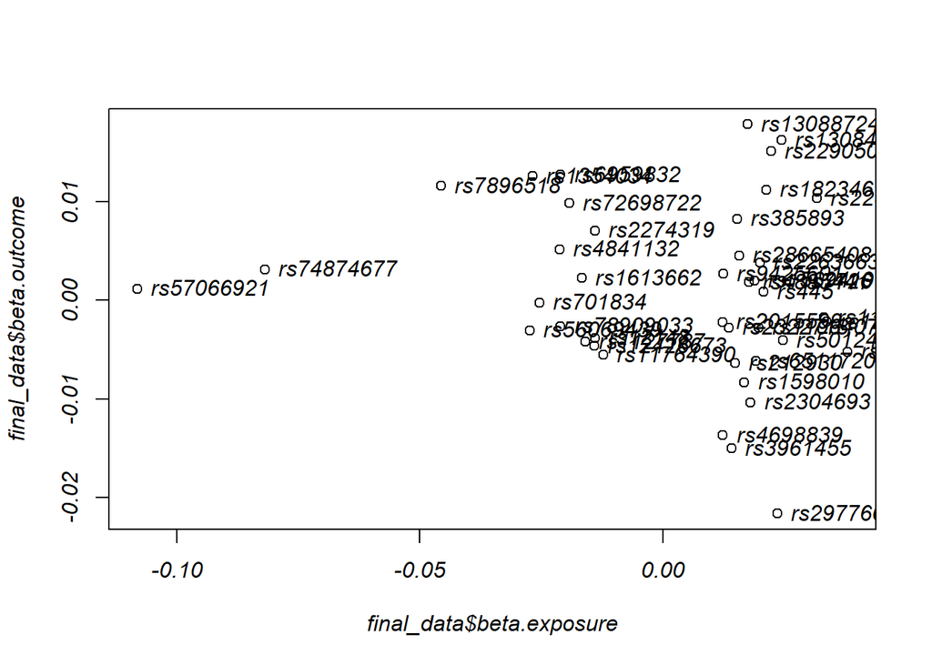

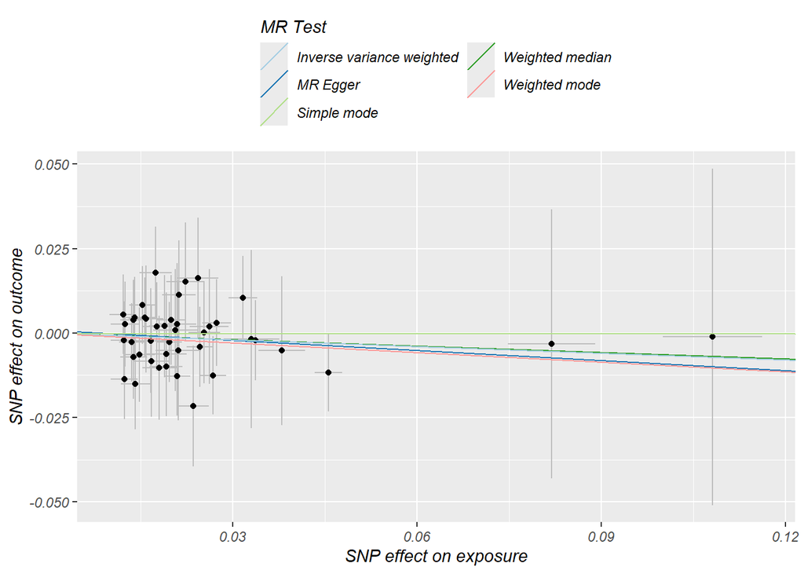

```
##   id.exposure id.outcome outcome exposure                    method        Q
## 1      xd1Q5E     AOkvNF outcome exposure                  MR Egger 15.14136
## 2      xd1Q5E     AOkvNF outcome exposure Inverse variance weighted 15.16567
##   Q_df    Q_pval
## 1   41 0.9999253
## 2   42 0.9999549
```

```
##   id.exposure id.outcome outcome exposure egger_intercept          se      pval
## 1      xd1Q5E     AOkvNF outcome exposure    0.0008211561 0.005267441 0.8768826
```

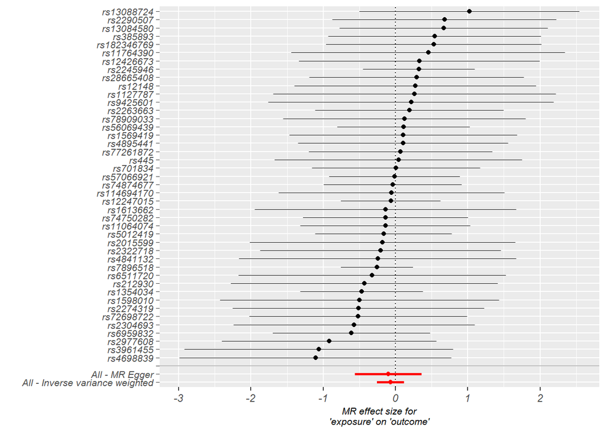

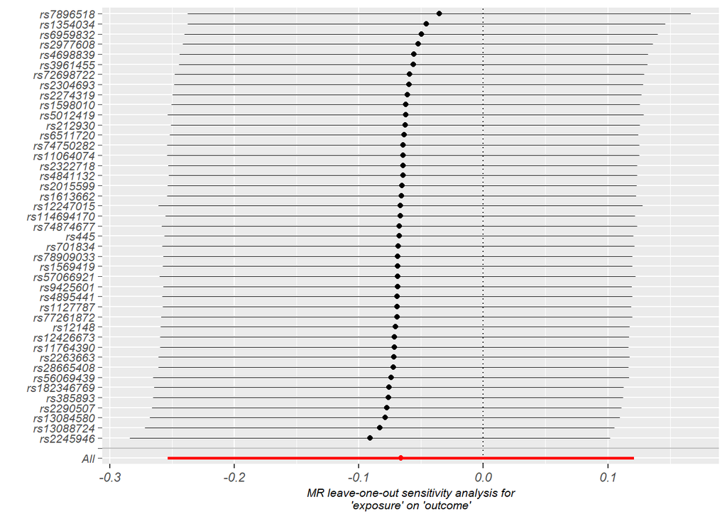

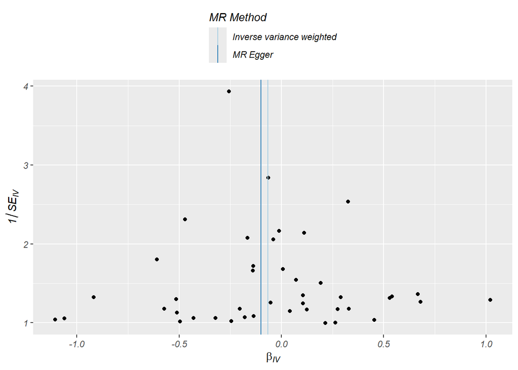

> Sensitivity Analyses With MendelianRandomization Package

```
##
## Inverse-variance weighted method
## (variants uncorrelated, random-effect model)
##
## Number of Variants : 43
##
## ------------------------------------------------------------------
##  Method Estimate Std Error  95% CI       p-value
##     IVW   -0.066     0.096 -0.254, 0.121   0.487
## ------------------------------------------------------------------
## Residual standard error =  0.601
## Residual standard error is set to 1 in calculation of confidence interval when its estimate is less than 1.
## Heterogeneity test statistic (Cochran's Q) = 15.1657 on 42 degrees of freedom, (p-value = 1.0000). I^2 = 0.0%.
## F statistic = 79.1.
```

```
##                     Method Estimate Std Error 95% CI        P-value
##              Simple median   -0.038     0.138  -0.309 0.232   0.780
##            Weighted median   -0.063     0.134  -0.327 0.200   0.637
##  Penalized weighted median   -0.063     0.134  -0.327 0.200   0.637
##
##                        IVW   -0.066     0.096  -0.254 0.121   0.487
##              Penalized IVW   -0.066     0.096  -0.254 0.121   0.487
##                 Robust IVW   -0.066     0.114  -0.289 0.156   0.560
##       Penalized robust IVW   -0.066     0.114  -0.289 0.156   0.560
##
##                   MR-Egger   -0.100     0.234  -0.558 0.359   0.670
##                (intercept)    0.001     0.005  -0.010 0.011   0.876
##         Penalized MR-Egger   -0.100     0.234  -0.558 0.359   0.670
##                (intercept)    0.001     0.005  -0.010 0.011   0.876
##            Robust MR-Egger   -0.110     0.220  -0.540 0.321   0.618
##                (intercept)    0.001     0.005  -0.009 0.011   0.832
##  Penalized robust MR-Egger   -0.110     0.220  -0.540 0.321   0.618
##                (intercept)    0.001     0.005  -0.009 0.011   0.832
```

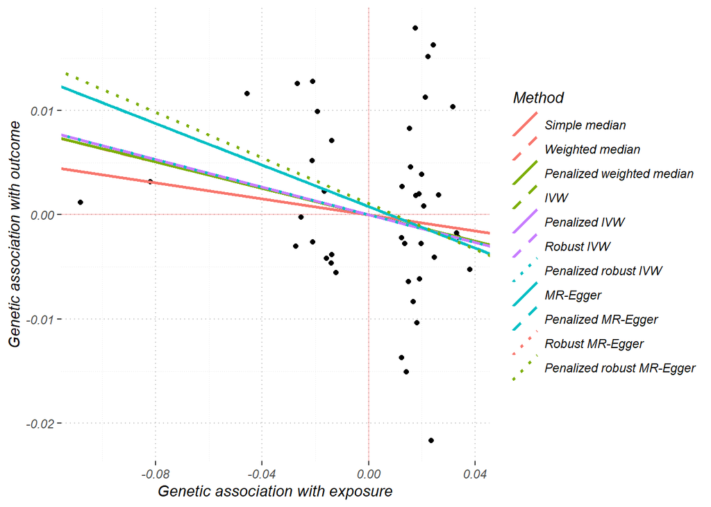

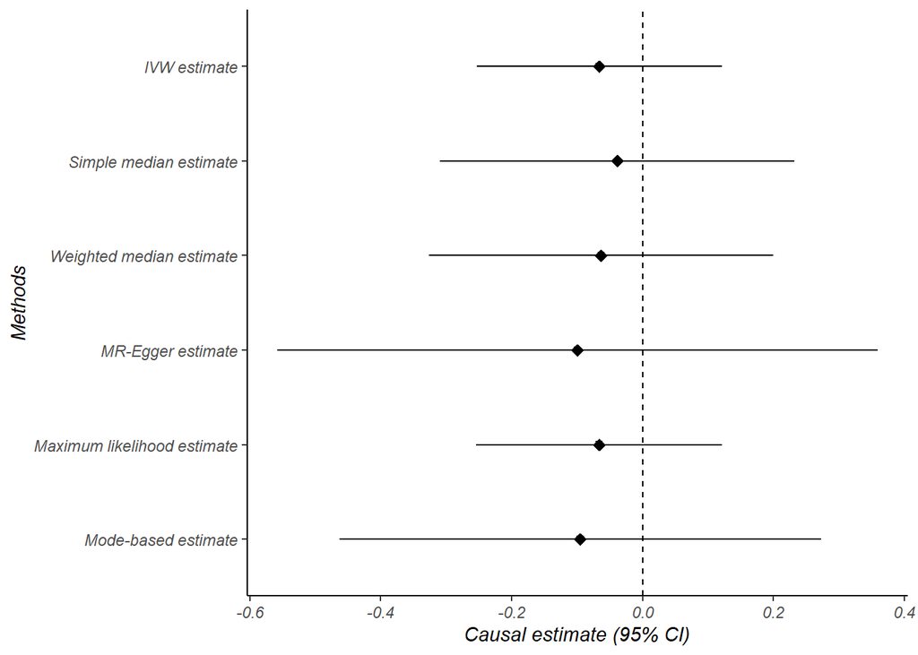

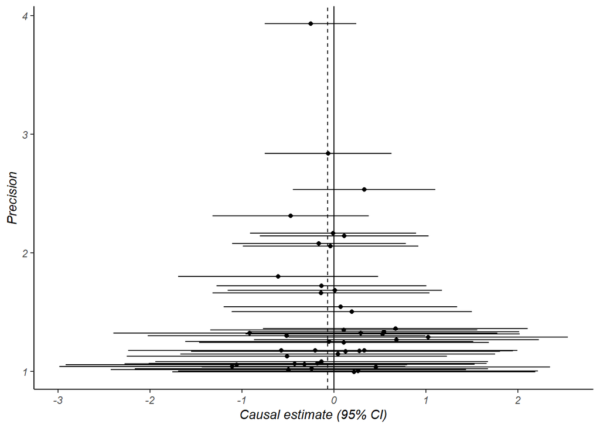

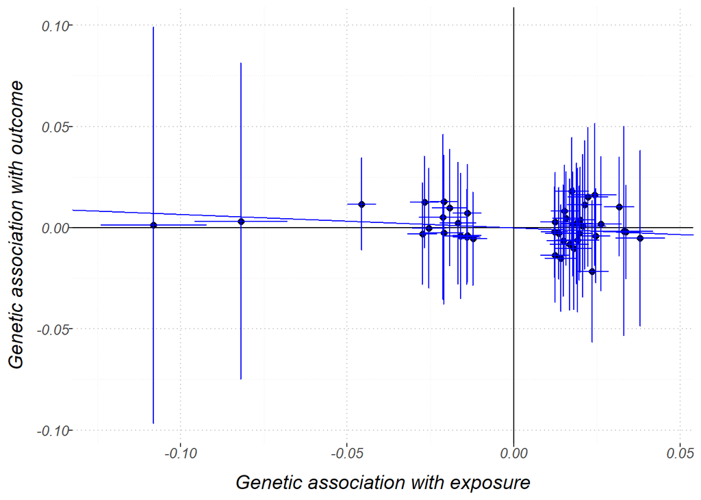

> MR Steiger Test of Directionality

| id.exposure | id.outcome | exposure | outcome | snp_r2.exposure | snp_r2.outcome | correct_causal_direction | steiger_pval |
| --- | --- | --- | --- | --- | --- | --- | --- |
| xd1Q5E | AOkvNF | exposure | outcome | 0.0089096 | 0.0012437 | TRUE | 0 |

```
## $r2_exp
## [1] 0
##
## $r2_out
## [1] 0.25
##
## $r2_exp_adj
## [1] 0
##
## $r2_out_adj
## [1] 0.25
##
## $correct_causal_direction
## [1] FALSE
##
## $steiger_test
## [1] 0
##
## $correct_causal_direction_adj
## [1] FALSE
##
## $steiger_test_adj
## [1] 0
##
## $vz
## [1] NaN
##
## $vz0
## [1] 0
##
## $vz1
## [1] NaN
##
## $sensitivity_ratio
## [1] NaN
##
## $sensitivity_plot
```

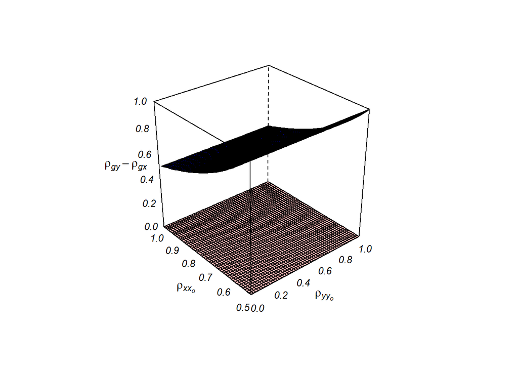

> Other MR Methods

```
## MR-RAPS method
```

```
## $beta.hat
## [1] -0.0666348
##
## $beta.se
## [1] 0.09715311
##
## $beta.p.value
## [1] 0.4927925
##
## $naive.se
## [1] 0.09653342
##
## $chi.sq.test
## [1] 15.1635
```

```
##   over.dispersion loss.function    beta.hat    beta.se
## 1           FALSE            l2 -0.06663480 0.09715311
## 2           FALSE         huber -0.06734012 0.09967724
## 3           FALSE         tukey -0.06677293 0.09967718
## 4            TRUE            l2 -0.06663370 0.09715582
## 5            TRUE         huber -0.06734012 0.09967743
## 6            TRUE         tukey -0.06677290 0.09967738
```

```
##
## MR-Lasso method
##
## Number of variants : 43
## Number of valid instruments : 43
## Tuning parameter : 0.2158568
## ------------------------------------------------------------------
##  Exposure Estimate Std Error  95% CI       p-value
##  exposure   -0.066     0.096 -0.254, 0.121   0.487
## ------------------------------------------------------------------
```

```
##
## Constrained maximum likelihood method (MRcML)
## Number of Variants:  43
## Results for:  cML-MA-BIC
## ------------------------------------------------------------------
##      Method Estimate    SE Pvalue         95% CI
##  cML-MA-BIC   -0.067 0.096  0.484 [-0.255,0.121]
## ------------------------------------------------------------------
```

```
##
## Debiased inverse-variance weighted method
## (Over.dispersion:TRUE)
##
## Number of Variants : 43
## ------------------------------------------------------------------
##  Method Estimate Std Error  95% CI       p-value Condition
##    dIVW   -0.067     0.097 -0.257, 0.122   0.487   512.422
## ------------------------------------------------------------------
```

```
##
## Mode-based method of Hartwig et al
## (weighted, delta standard errors [not assuming NOME], bandwidth factor = 1)
##
## Number of Variants : 43
## ------------------------------------------------------------------
##  Method Estimate Std Error  95% CI       p-value
##     MBE   -0.095     0.192 -0.471, 0.281   0.620
## ------------------------------------------------------------------
```

## MSP on mtDNA-CN

### Title: Exploring the Causal Impact of **MSP** on **mtDNA-CN**

> Introduction
- Exposure: MSP | GWAS summary statistics: [International Multiple Sclerosis Genetics Consortium (IMSGC)](https://imsgc.net/?page_id=31) | Reference paper: [Harroud et al. 2023](https://pubmed.ncbi.nlm.nih.gov/37380766/)
- Sample size: 12,584
- Ancestry: European
- Outcome: mtDNA-cn | GWAS summary statistics: [GWAS catalogue](https://www.ebi.ac.uk/gwas/publications/35023831) | Reference paper: [Chong et al. 2022](https://pubmed.ncbi.nlm.nih.gov/35023831/)
- Sample size: 383,476
- Ancestry: European

> Data Prepration
- Number of total SNPs in exposure: 7,776,916 SNPs
- Number of SNPs exposure with p-value < $5\times10^{-5}$: 356 SNPs
- Number of SNPs exposure after clumping: 87 SNPs
- Number of total SNPs in outcome: 11,453,766 SNPs
- Number of common variants between exposure and outcome: 87 SNPs
- Number of SNPs after harmonization (action=2): 87 SNPs

> Weakness of Instruments

```
##    Min. 1st Qu.  Median    Mean 3rd Qu.    Max.
##   16.50   17.21   18.25   18.86   19.76   32.90
```

The number of SNPs eliminated through the process of checking for weakness: 0 SNP

> Initial MR

```
##   id.exposure id.outcome outcome exposure                    method nsnp
## 1      nURK4f     T2q0Df outcome exposure                  MR Egger   87
## 2      nURK4f     T2q0Df outcome exposure           Weighted median   87
## 3      nURK4f     T2q0Df outcome exposure Inverse variance weighted   87
## 4      nURK4f     T2q0Df outcome exposure               Simple mode   87
## 5      nURK4f     T2q0Df outcome exposure             Weighted mode   87
##              b          se      pval
## 1  0.005811470 0.009729050 0.5518739
## 2 -0.005626420 0.006612471 0.3948360
## 3 -0.001397526 0.004472366 0.7546756
## 4 -0.021834722 0.016511154 0.1895337
## 5 -0.020182425 0.014857264 0.1778828
```

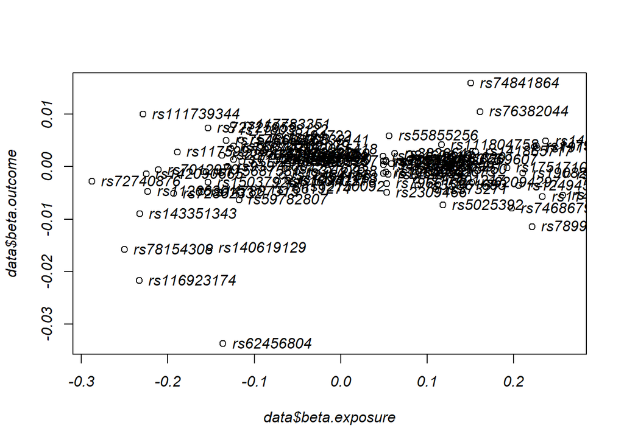

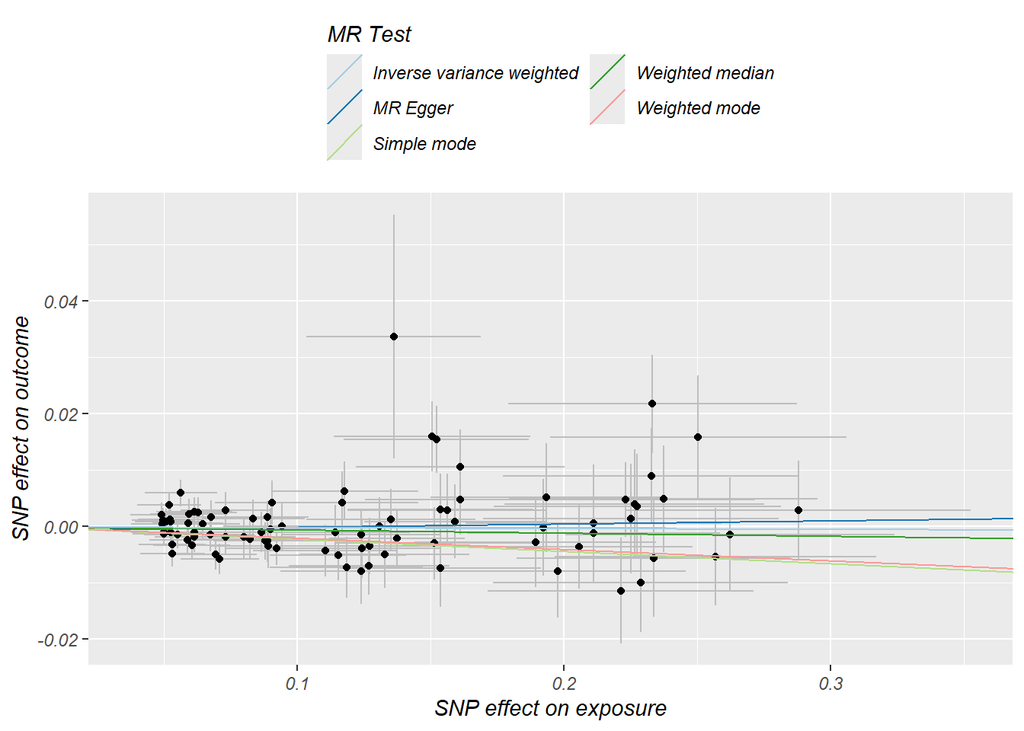

```
##   id.exposure id.outcome outcome exposure                    method        Q
## 1      nURK4f     T2q0Df outcome exposure                  MR Egger 88.44734
## 2      nURK4f     T2q0Df outcome exposure Inverse variance weighted 89.17241
##   Q_df    Q_pval
## 1   85 0.3775598
## 2   86 0.3860270
```

```
##   id.exposure id.outcome outcome exposure egger_intercept           se
## 1      nURK4f     T2q0Df outcome exposure   -0.0006964723 0.0008343435
##        pval
## 1 0.4061958
```

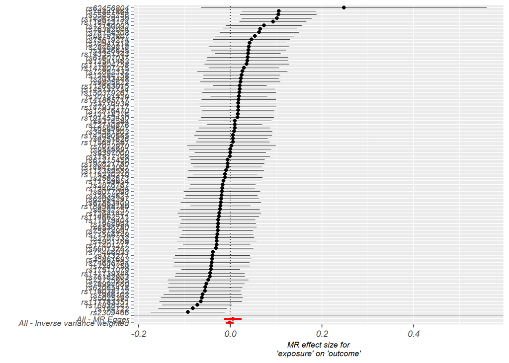

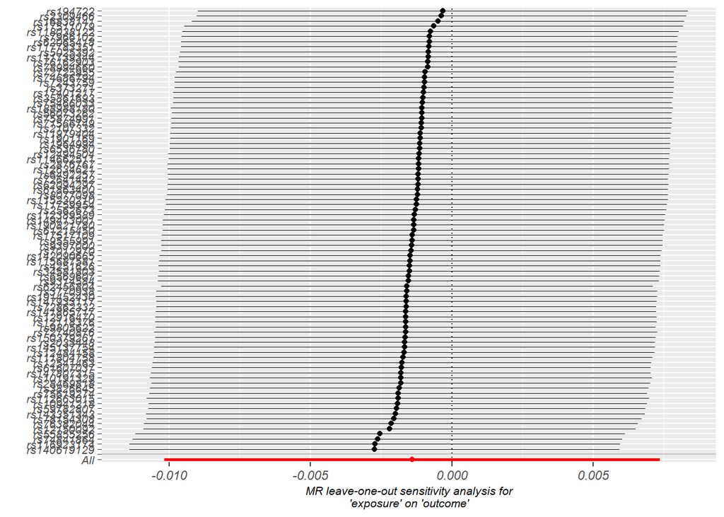

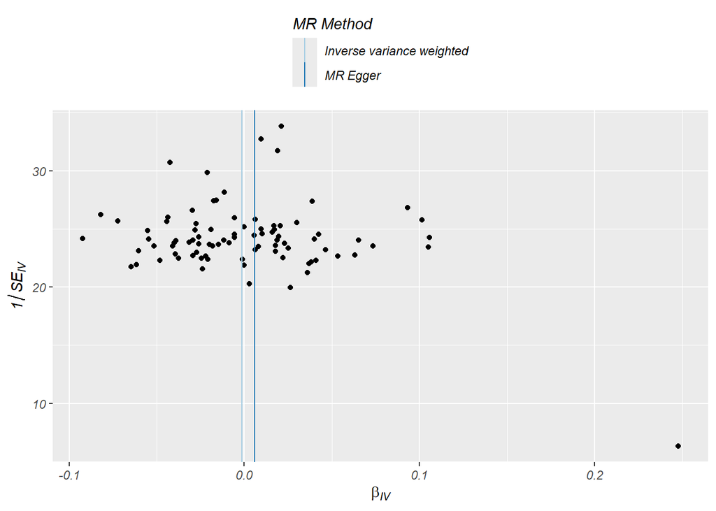

> MR-PRESSO Test

```
## $`Main MR results`
##        Exposure       MR Analysis Causal Estimate          Sd     T-stat
## 1 beta.exposure               Raw    -0.001397526 0.004472366 -0.3124802
## 2 beta.exposure Outlier-corrected              NA          NA         NA
##     P-value
## 1 0.7554321
## 2        NA
##
## $`MR-PRESSO results`
## $`MR-PRESSO results`$`Global Test`
## $`MR-PRESSO results`$`Global Test`$RSSobs
## [1] 91.25201
##
## $`MR-PRESSO results`$`Global Test`$Pvalue
## [1] 0.389
```

> RadialMR Test

```
##
## Radial IVW
##
##                      Estimate   Std.Error    t value  Pr(>|t|)
## Effect (Mod.2nd) -0.001397539 0.004472371 -0.3124829 0.7546735
## Iterative        -0.001397539 0.004472371 -0.3124829 0.7546735
## Exact (FE)       -0.001478970 0.004392249 -0.3367226 0.7363260
## Exact (RE)       -0.001481647 0.004598976 -0.3221688 0.7481066
##
##
## Residual standard error: 1.018 on 86 degrees of freedom
##
## F-statistic: 0.1 on 1 and 86 DF, p-value: 0.755
## Q-Statistic for heterogeneity: 89.16685 on 86 DF , p-value: 0.3861855
##
##  No significant outliers
## Number of iterations = 2
```

```
## [1] "No significant outliers"
```

> Standardized Residuals

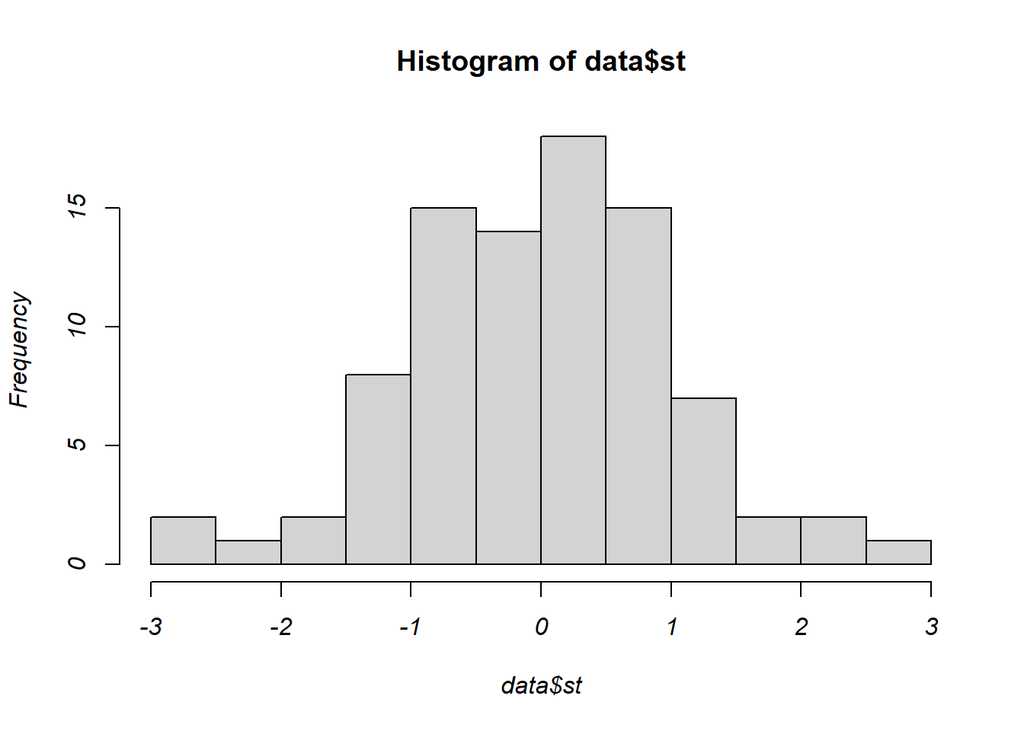

```
## integer(0)
```

> Cook’s Distance

“In statistics, Cook’s distance or Cook’s D is a commonly used estimate of the influence of a data point when performing a least-squares regression analysis. In a practical ordinary least squares analysis, Cook’s distance can be used in several ways: to indicate influential data points that are particularly worth checking for validity; or to indicate regions of the design space where it would be good to be able to obtain more data points. It is named after the American statistician R. Dennis Cook, who introduced the concept in 1977” ([Refernce](https://en.wikipedia.org/wiki/Cook%27s_distance)).

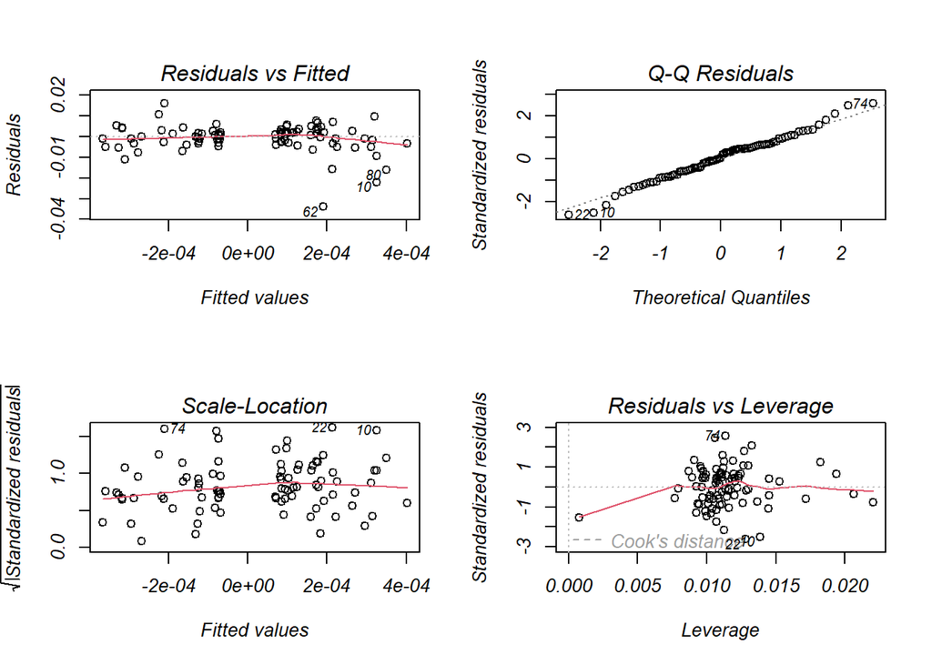

> Potential Outliers and Influential SNPs

```
## rs116923174 rs140619129 rs62456804 rs74841864 rs78154308 rs55855256 rs2309466 rs12150092 rs76382044 rs143351343 rs59782807
```

> MR Analysis After Deleting Outliers and Influential SNPs

```
##   id.exposure id.outcome outcome exposure                    method nsnp
## 1      nURK4f     T2q0Df outcome exposure                  MR Egger   76
## 2      nURK4f     T2q0Df outcome exposure           Weighted median   76
## 3      nURK4f     T2q0Df outcome exposure Inverse variance weighted   76
## 4      nURK4f     T2q0Df outcome exposure               Simple mode   76
## 5      nURK4f     T2q0Df outcome exposure             Weighted mode   76
##              b          se       pval
## 1 -0.011424357 0.010405963 0.27582231
## 2 -0.010549743 0.006372131 0.09780147
## 3 -0.009826027 0.004673517 0.03551030
## 4 -0.023368650 0.016816998 0.16876632
## 5 -0.022205338 0.017238043 0.20165073
```

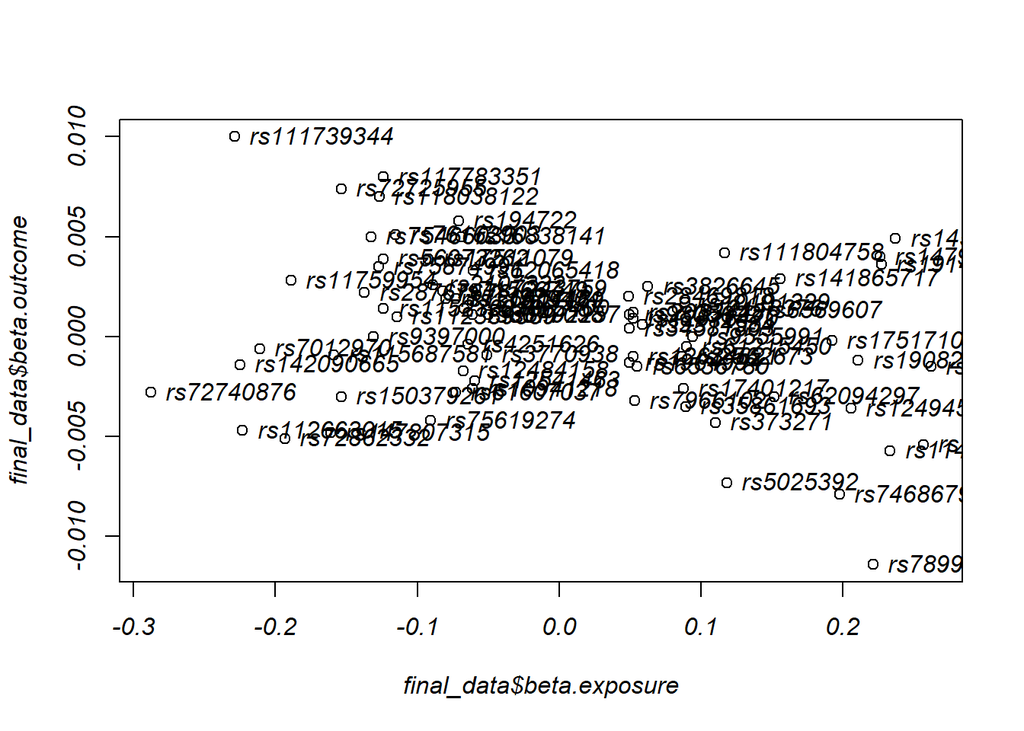

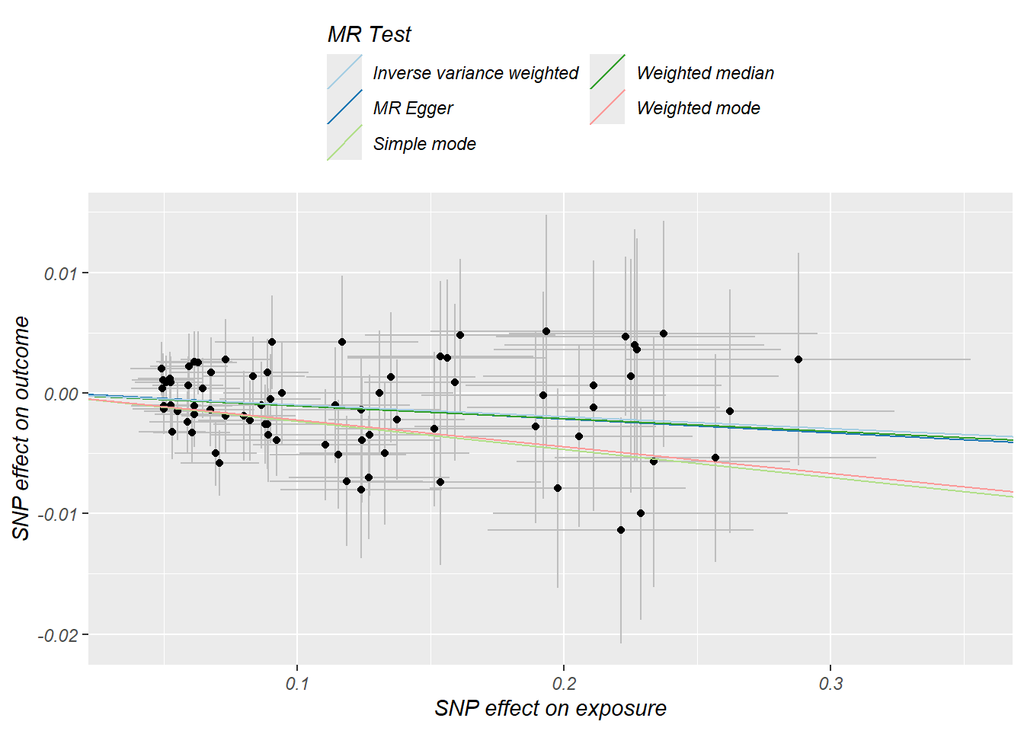

```
##   id.exposure id.outcome outcome exposure                    method        Q
## 1      nURK4f     T2q0Df outcome exposure                  MR Egger 41.68274
## 2      nURK4f     T2q0Df outcome exposure Inverse variance weighted 41.71229
##   Q_df    Q_pval
## 1   74 0.9991256
## 2   75 0.9993510
```

```
##   id.exposure id.outcome outcome exposure egger_intercept         se      pval
## 1      nURK4f     T2q0Df outcome exposure    0.0001523749 0.00088636 0.8639769
```

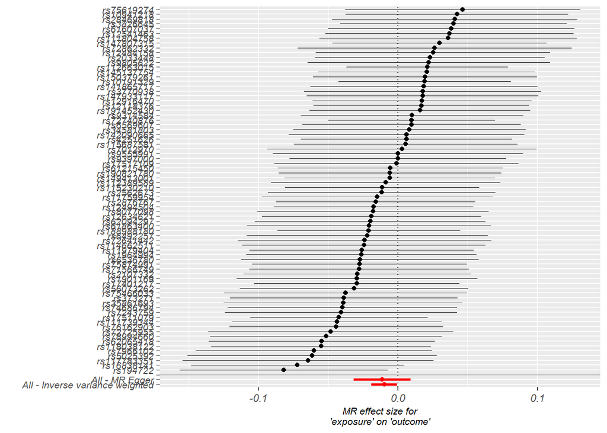

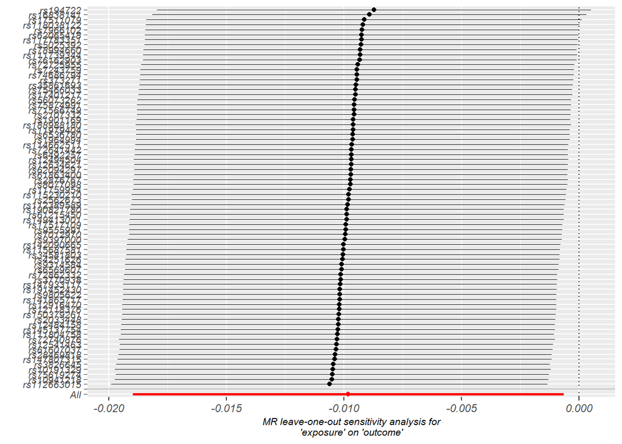

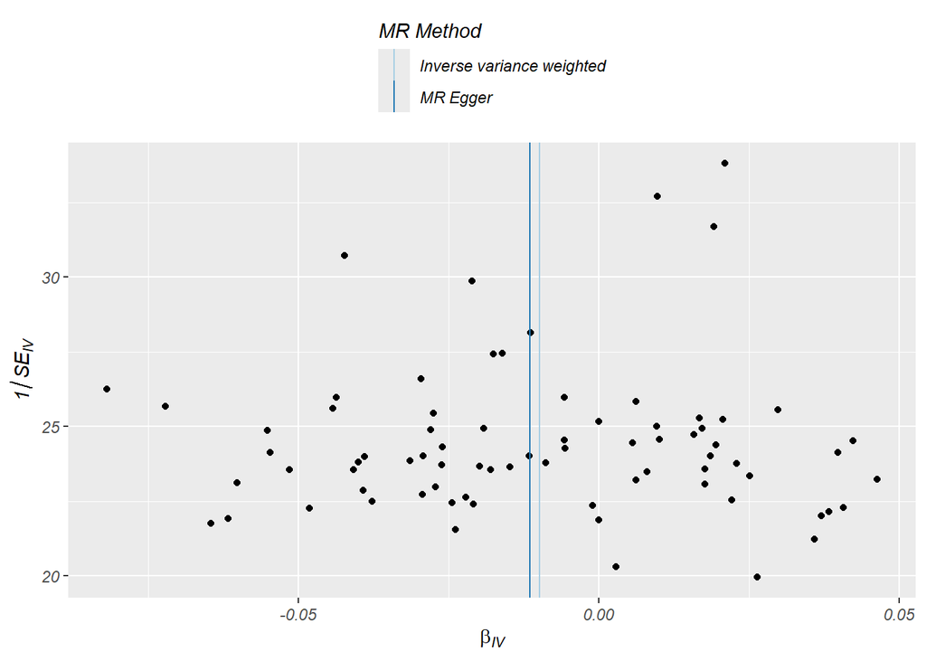

> Sensitivity Analyses With MendelianRandomization Package

```
##
## Inverse-variance weighted method
## (variants uncorrelated, random-effect model)
##
## Number of Variants : 76
##
## ------------------------------------------------------------------
##  Method Estimate Std Error  95% CI        p-value
##     IVW   -0.010     0.005 -0.019, -0.001   0.036
## ------------------------------------------------------------------
## Residual standard error =  0.746
## Residual standard error is set to 1 in calculation of confidence interval when its estimate is less than 1.
## Heterogeneity test statistic (Cochran's Q) = 41.7123 on 75 degrees of freedom, (p-value = 0.9994). I^2 = 0.0%.
## F statistic = 19.0.
```

```
##                     Method Estimate Std Error 95% CI         P-value
##              Simple median   -0.011     0.006  -0.024  0.001   0.077
##            Weighted median   -0.011     0.006  -0.024  0.001   0.079
##  Penalized weighted median   -0.011     0.006  -0.024  0.001   0.079
##
##                        IVW   -0.010     0.005  -0.019 -0.001   0.036
##              Penalized IVW   -0.010     0.005  -0.019 -0.001   0.036
##                 Robust IVW   -0.009     0.004  -0.018 -0.001   0.029
##       Penalized robust IVW   -0.009     0.004  -0.018 -0.001   0.029
##
##                   MR-Egger   -0.011     0.010  -0.032  0.009   0.272
##                (intercept)    0.000     0.001  -0.002  0.002   0.864
##         Penalized MR-Egger   -0.011     0.010  -0.032  0.009   0.272
##                (intercept)    0.000     0.001  -0.002  0.002   0.864
##            Robust MR-Egger   -0.011     0.008  -0.028  0.005   0.171
##                (intercept)    0.000     0.001  -0.001  0.002   0.793
##  Penalized robust MR-Egger   -0.011     0.008  -0.028  0.005   0.171
##                (intercept)    0.000     0.001  -0.001  0.002   0.793
```

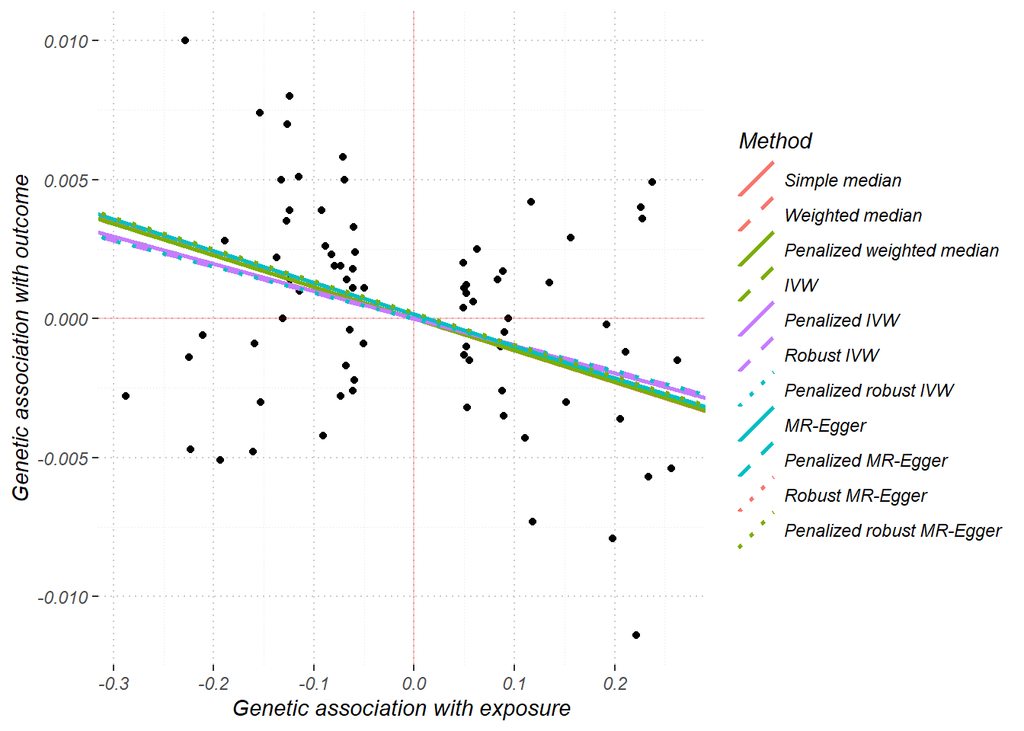

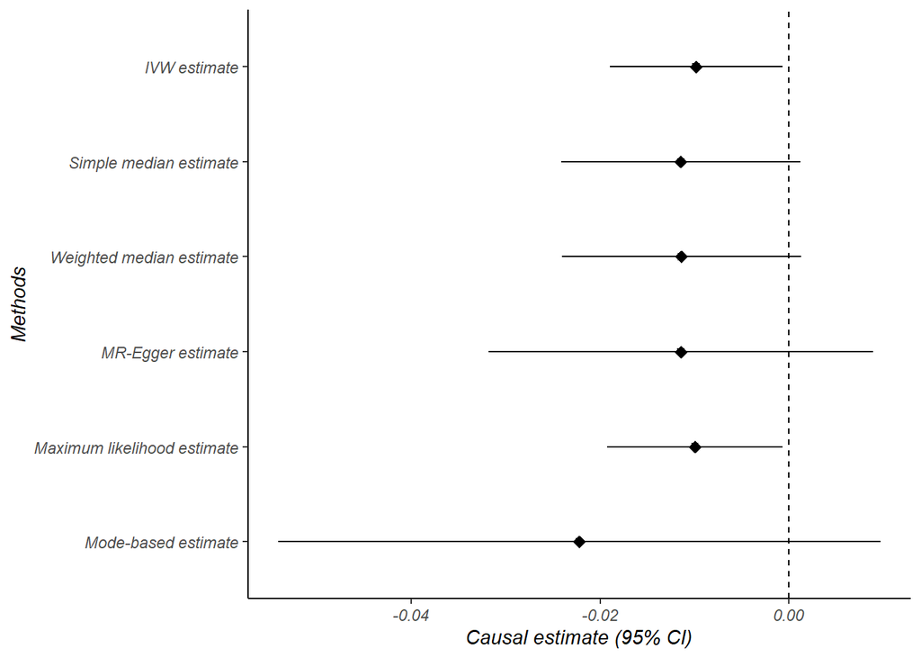